# Лабораторная работа №1

Простые модели компьютерной сети

Оширова Ю. Н.

Российский университет дружбы народов, Москва, Россия

16 февраля 2025

# Информация

## Докладчик

- Оширова Юлия Николаевна
- студентка группы НФИбд-01-22
- Российский университет дружбы народов

# Цель работы

Приобрести навыки моделирования сетей передачи данных с помощью средства имитационного моделирования NS-2, а также проанализировать полученные результаты моделирования.

# Задание

1. Создать шаблон сценария для NS-2;
2. Выполнить простой пример описания топологии сети, состоящей из двух узлов и одного соединения;
3. Выполнить пример с усложнённой топологией сети;
4. Выполнить пример с кольцевой топологией сети;
5. Выполнить упражнение.

# Выполнение лабораторной работы

## Шаблон сценария для NS-2

В своём рабочем каталоге создадим директорию mip, в которой будут выполняться лабораторные работы. Внутри mip создадим директорию lab-ns, а в ней файл shablon.tcl (рис. [-@fig:001]).

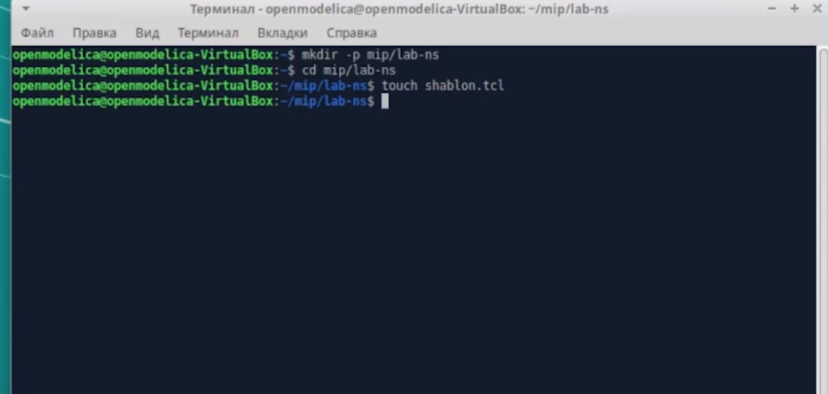

Шаблон для сценария

Откроем на редактирование файл shablon.tcl (рис. [-@fig:002]).

Сначала создадим объект типа Simulator. Затем создадим переменную nf и укажем, что требуется открыть на запись nam-файл для регистрации выходных результатов моделирования. Вторая строка даёт команду симулятору записывать все данные о динамике модели в файл out.nam. Далее создадим переменную f и откроем на запись файл трассировки для регистрации всех событий модели. После этого добавим процедуру finish, которая закрывает файлы трассировки и запускает nam. С помощью команды at указываем планировщику событий, что процедуру finish запустим через 5 с после начала моделирования, после чего запустим симулятор ns.

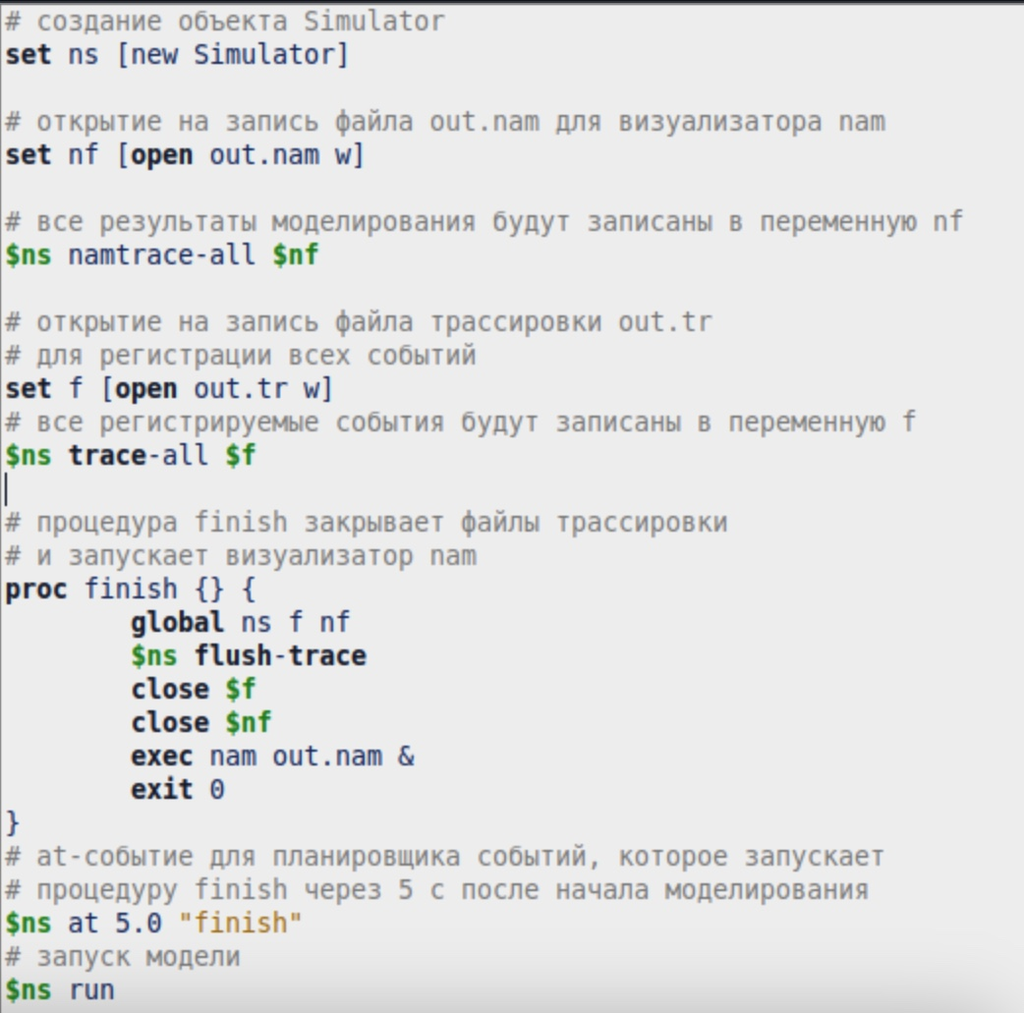

Добавление кода

Сохранив изменения в отредактированном файле shablon.tcl и закрыв его, запустим симулятор командой ns shablon.tcl. Увидим пустую область моделирования, поскольку ещё не определены никакие объекты и действия (рис. [-@fig:003]).

[figure not shown]

Область моделирования

## Простой пример описания топологии сети, состоящей из двух узлов и одного соединения

Требуется смоделировать сеть передачи данных, состоящую из двух узлов, соединённых дуплексной линией связи с полосой пропускания 2 Мб/с и задержкой 10 мс, очередью с обслуживанием типа DropTail. От одного узла к другому по протоколу UDP осуществляется передача пакетов, размером 500 байт, с постоянной скоростью 200 пакетов в секунду.

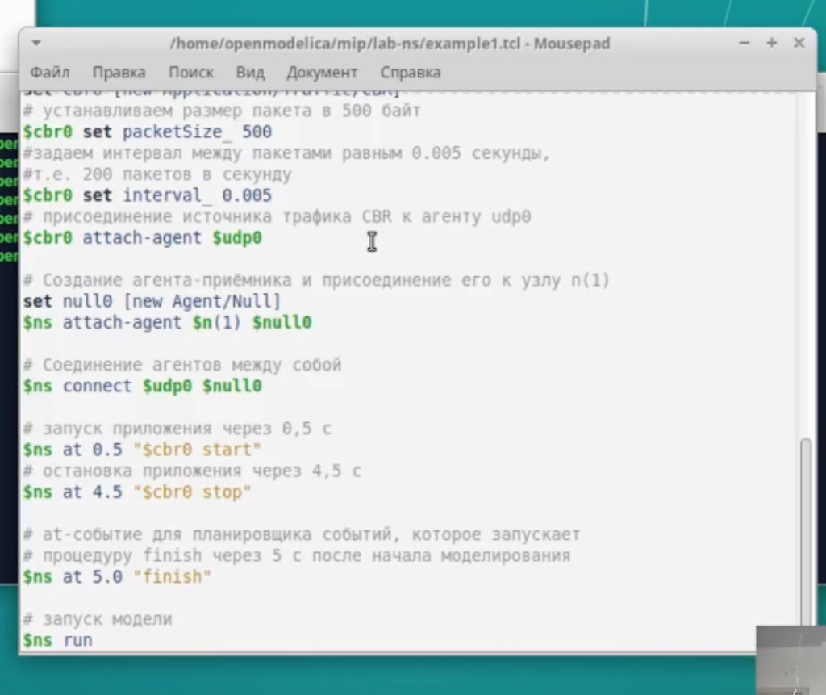

Добавление кода

Сохранив изменения в отредактированном файле и запустив симулятор, получим в качестве результата запуск аниматора nam в фоновом режиме (рис. [-@fig:005]).

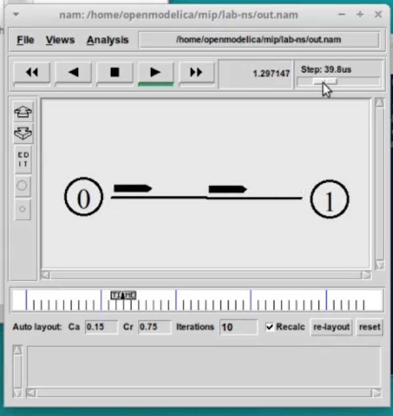

Область моделирования

При нажатии на кнопку play в окне nam через 0.5 секунды из узла 0 данные начнут поступать к узлу 1.

## Пример с усложнённой топологией сети

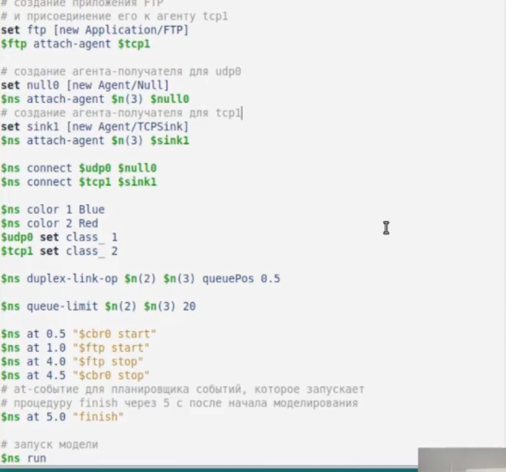

Добавление кода

## Сохранив изменения в отредактированном файле и запустив симулятор, получим анимированный результат моделирования (рис. [-@fig:007]).

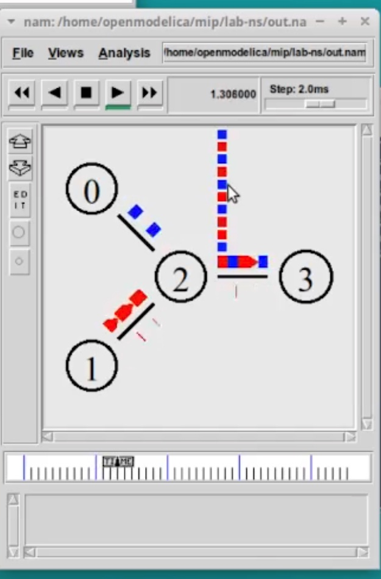

Область моделирования

## Пример с кольцевой топологией сети

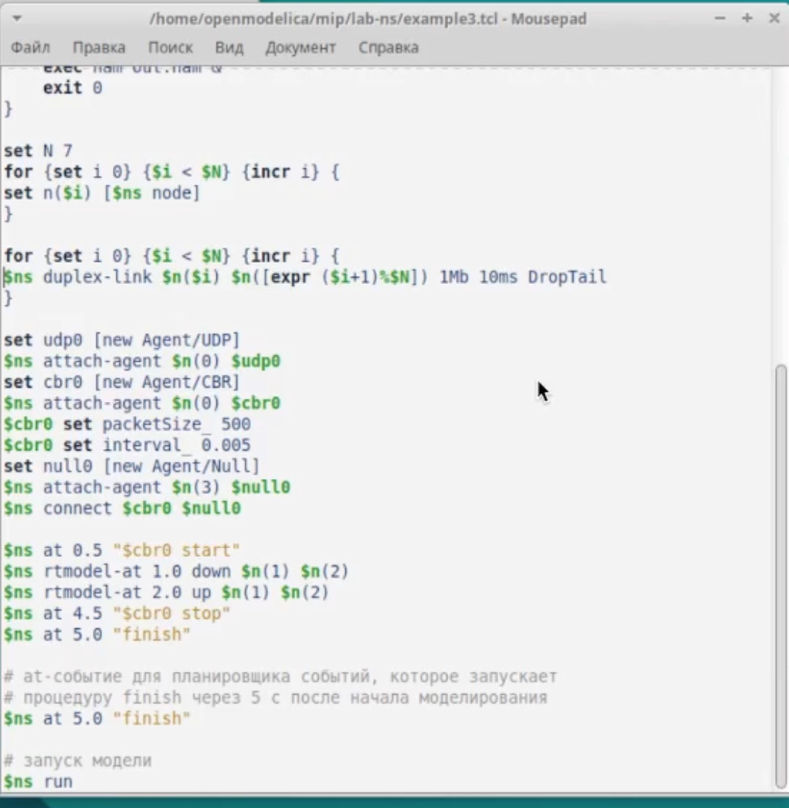

Добавление кода

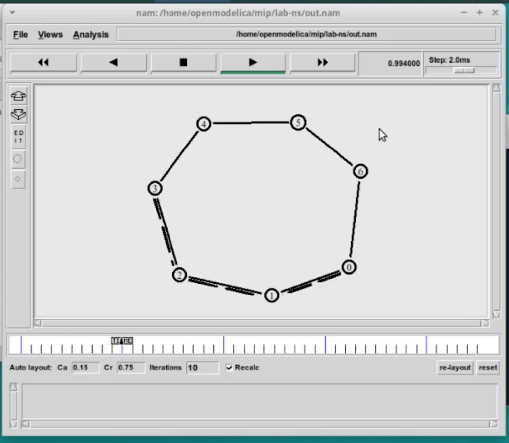

Область моделирования

## Передача данных при кольцевой топологии сети в случае разрыва соединения представлена на рис. [-@fig:010].

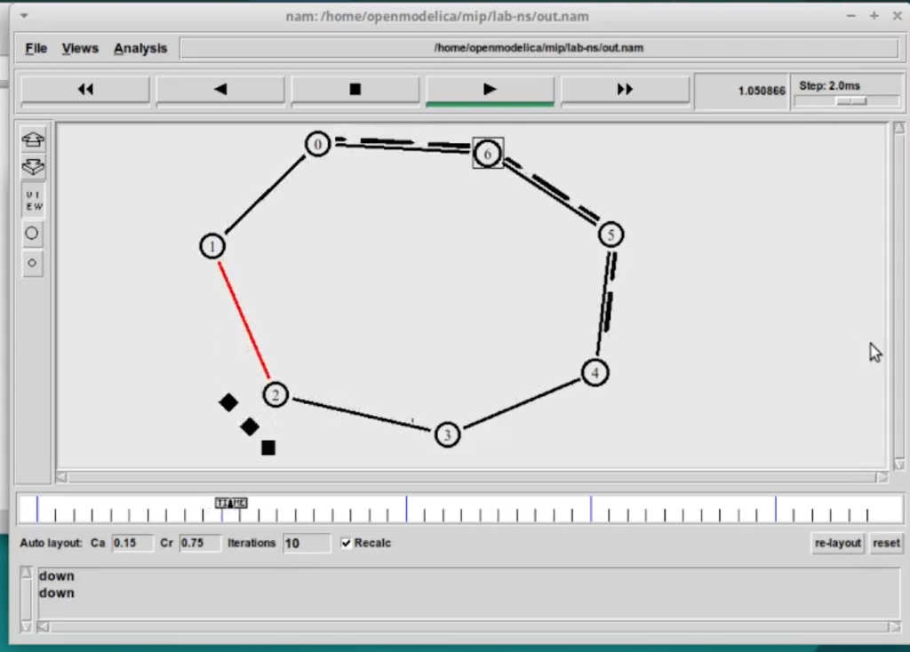

Область моделирования

Добавив в начало скрипта после команды создания объекта Simulator:

$ns rtproto DV

увидим, что сразу после запуска в сети отправляется небольшое количество маленьких пакетов, используемых для обмена информацией, необходимой для маршрутизации между узлами (рис. [-@fig:011]). Когда соединение будет разорвано, информация о топологии будет обновлена, и пакеты будут отсылаться по новому маршруту через узлы n(6), n(5) и n(4).

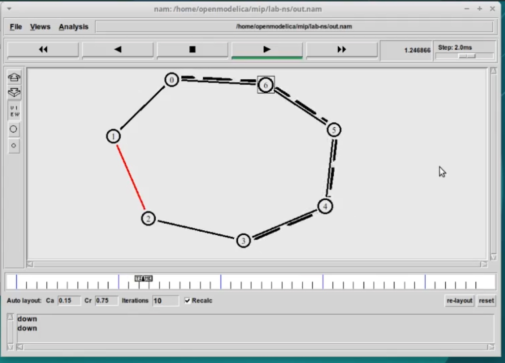

Область моделирования

## Упражнение

Внесем следующие изменения в реализацию примера с кольцевой топологией сети:

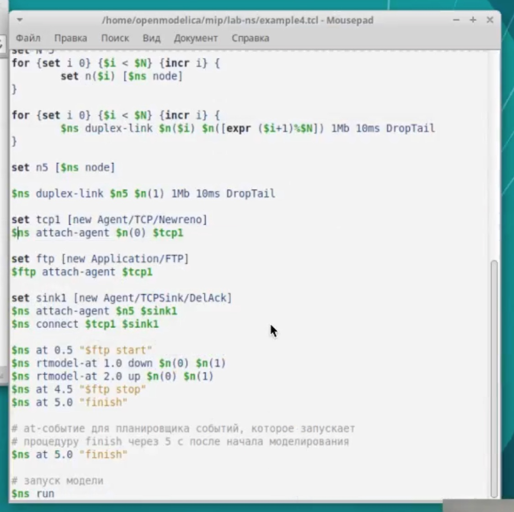

Добавление кода

## Запустим программу и увидим, что пакеты идут по кратчайшему пути через узел n(1) ([-@fig:013]).

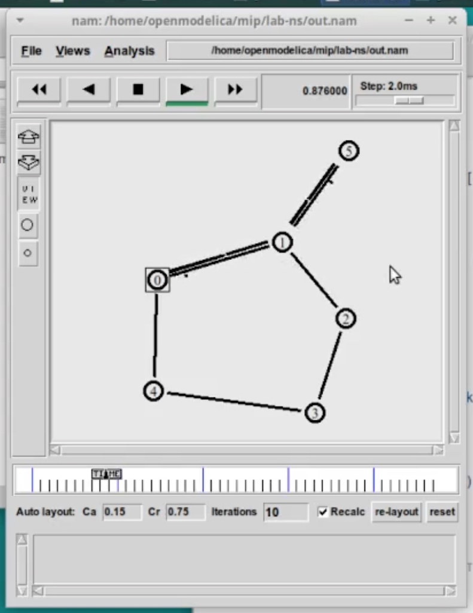

Область моделирования

## При разрыве соединения часть пакетов теряется, но поскольку данные обновляются пакеты начинают идти по другому пути ([-@fig:014]).

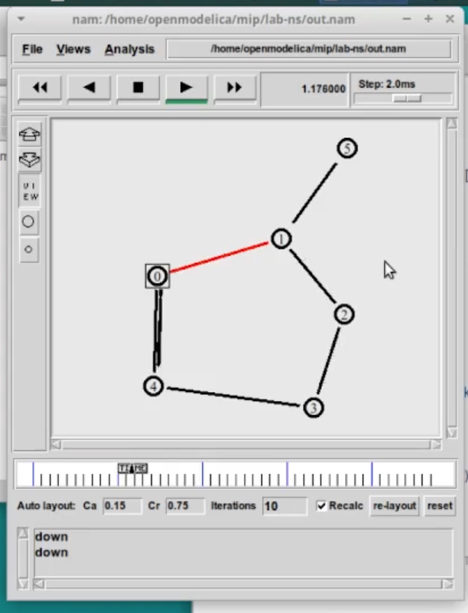

Область моделирования

## После восстановления соединения пакеты снова идут по кратчайшему пути ([-@fig:015]).

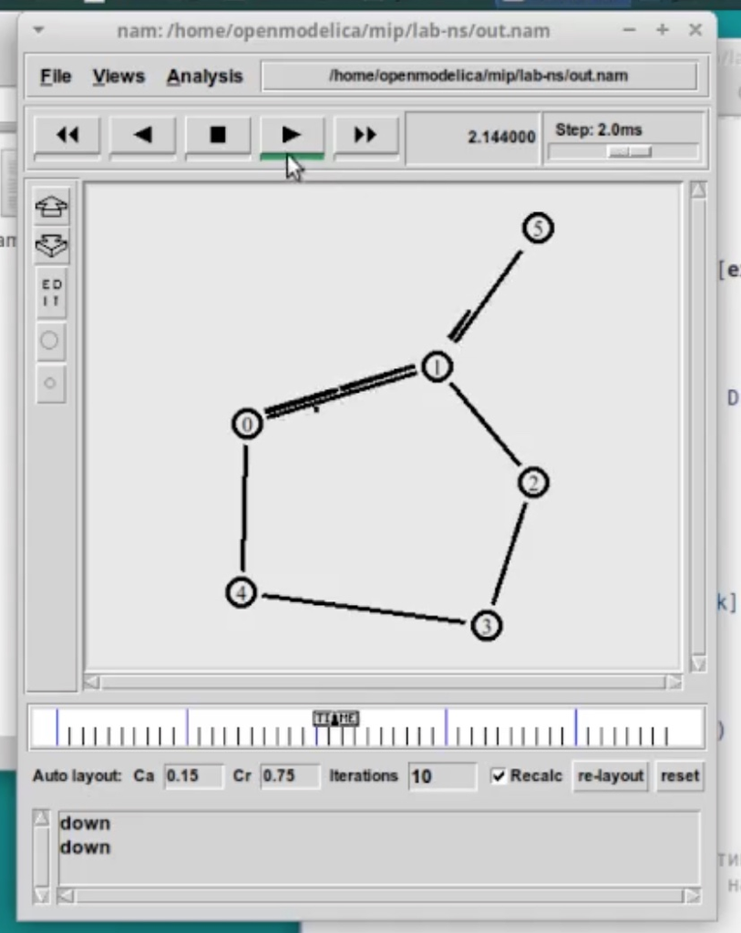

Область моделирования

# Выводы

В процессе выполнения данной лабораторной работы я приобрела навыки моделирования сетей передачи данных с помощью средства имитационного моделирования NS-2, а также проанализировала полученные результаты моделирования.